# index

## Tracking the Adoption of Electric Vehicles in Washington State

### Contributors

Esha Bantwal - ebantwal@uw.edu  
Efra Ahsan - eahsan@uw.edu  
Lily Shen - lilyshen@uw.edu Safa Jamal - safaj03@uw.edu

June 2nd, 2022

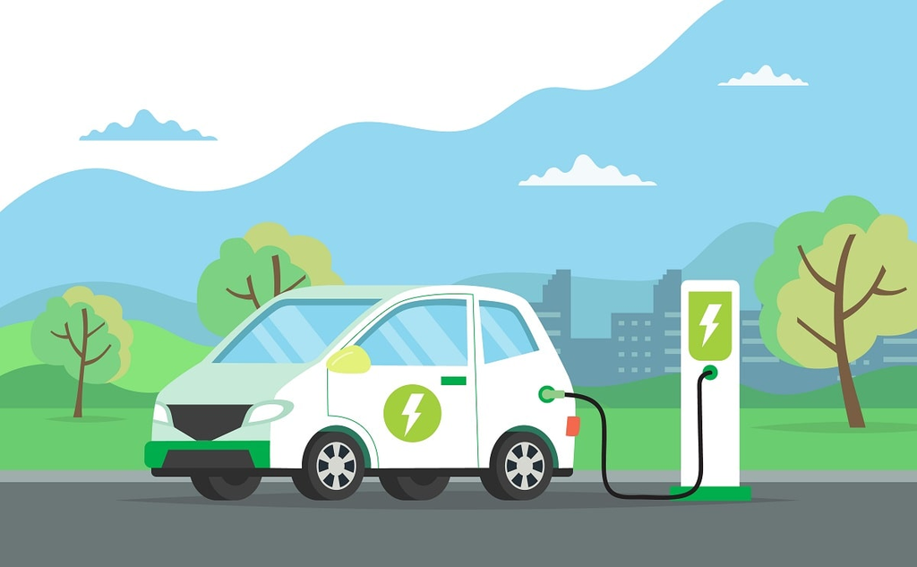

“electric vehicles”

## Questions

The role of vehicles and fuel emissions in climate change has been gaining increasing attention over the past years. Through our analysis we aim to answer the following questions:

- **What are the most efficient electric vehicles based on electric range?**
- **How does the amount of electric vehicles with CAFV vary based on the city?**
- **How does the number of vehicles fluctuate per region?**

We ask such questions because as technology advances and engineers develop more electric vehicles to reduce the amount of carbon dioxide emissions, it’s important to remember that these vehicles still require lots of other energy to function, if not gasoline. Thus, with this project, we will be identifying and collecting data to demonstrate whether electric vehicles are a benefit or harm to the state of Washington.

## The Dataset

In order to answer these questions, we will be using data about electric vehicles in Washington State collected by the DOL.We found this dataset, [Electric Vehicle Population Data](https://data.wa.gov/Transportation/Electric-Vehicle-Population-Data/f6w7-q2d2), in the U.S. Government’s open data resource called Data.gov.

## Limitations

One problem with this set is that the ‘Electric Range’ feature (indicating the distance the vehicle can travel) is no longer maintained, so although some vehicles have data expressing this information, many others do not. Along the same lines, the ‘Field Electric Utility’ feature (indicating the electric retail service of the vehicle’s registered location) was added almost 2 years after this set’s initial collection, meaning there is more missing information. A further limitation to this new ‘Field Electric Utility’ feature is that there’s only about a month’s worth of information for us to currently see. The inconsistency with the missing data here is a major drawback since there is more information we would need to research ourself and match directly with the data we do have, which is a lot. Additionally, both of these features are researched and manually inputted, such as the Electric Range of a vehicle, so there is room for there to be errors in this manual inputting of information. Lastly, another huge limitation is the dataset does not provide the registration date, so we cannot track the registration of models over a time frame.